# STAT 413/613: HW on List Columns and COVID19

# 13 Analyze US States Deaths **Extra Credit**

1. Create a data frame with the total deaths and deaths per population for those US states with more than 0 deaths and more than 0 population.

```r
df_allp %>%
  filter(Country_Region == "US") %>%
  filter(case_type == "deaths_US") %>%
  group_by(Country_State) %>%
  summarise(TolDth_byState = max(Cases),
            Dthper_byState = TolDth_byState/(PopTotal*1000)) %>%
  distinct() ->
  df_US_Dth
df_US_Dth %>%
  filter(TolDth_byState > 0) ->
  df_US_Dth
df_US_Dth
```

```
## # A tibble: 56 x 3
## # Groups:   Country_State [56]
##    Country_State           TolDth_byState Dthper_byState
##    <chr>                            <dbl>          <dbl>
##  1 US_Alabama                        1487    0.00000452
##  2 US_Alaska                          165    0.000000501
##  3 US_Arizona                        9733    0.0000296
##  4 US_Arkansas                        634    0.00000193
##  5 US_California                    23493    0.0000714
##  6 US_Colorado                        790    0.00000240
##  7 US_Connecticut                    2355    0.00000716
##  8 US_Delaware                        788    0.00000239
##  9 US_District of Columbia           1081    0.00000329
## 10 US_Florida                        5981    0.0000182
## # … with 46 more rows
```

2. Use an appropriate plot to assess for a linear relationship between total deaths and deaths per population using log scales for x and y axes. Interpret the plot.

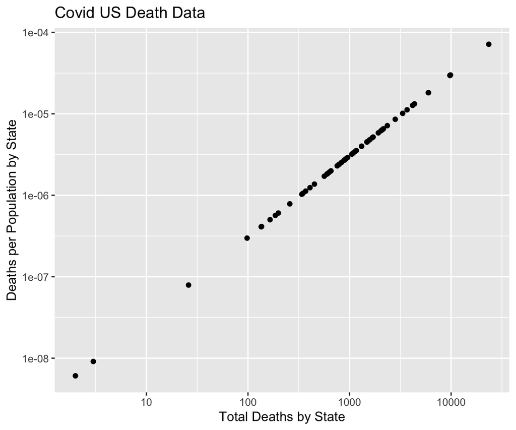

```r
df_US_Dth %>%
  ggplot(aes(x = TolDth_byState, y = Dthper_byState)) +
  geom_point() +
  scale_x_log10() +
  scale_y_log10() +
  ggtitle("Covid US Death Data") +
  xlab("Total Deaths by State") +
  ylab("Deaths per Population by State")
```

```r
# Based on the plot, we can see that there is a positive correlation between total deaths and deaths per population
```

3. Run a linear model to test for a linear relationship and interpret the results in terms of p value, adjusted R-squared and a plot of the residuals.

```r
 lm(Dthper_byState ~ TolDth_byState, data  = df_US_Dth) ->
  lmout2
summary(lmout2)
```

```
##
## Call:
## lm(formula = Dthper_byState ~ TolDth_byState, data = df_US_Dth)
##
## Residuals:
##        Min         1Q     Median         3Q        Max
## -1.047e-20 -1.268e-21 -9.700e-22 -5.170e-22  5.260e-20
##
## Coefficients:
##                 Estimate Std. Error   t value Pr(>|t|)
## (Intercept)    3.622e-21  1.150e-21 3.151e+00  0.00265 **
## TolDth_byState 3.039e-09  2.675e-25 1.136e+16  < 2e-16 ***
## ---
## Signif. codes:  0 '***' 0.001 '**' 0.01 '*' 0.05 '.' 0.1 ' ' 1
##
## Residual standard error: 7.389e-21 on 54 degrees of freedom
## Multiple R-squared:      1,  Adjusted R-squared:      1
## F-statistic: 1.29e+32 on 1 and 54 DF,  p-value: < 2.2e-16
```

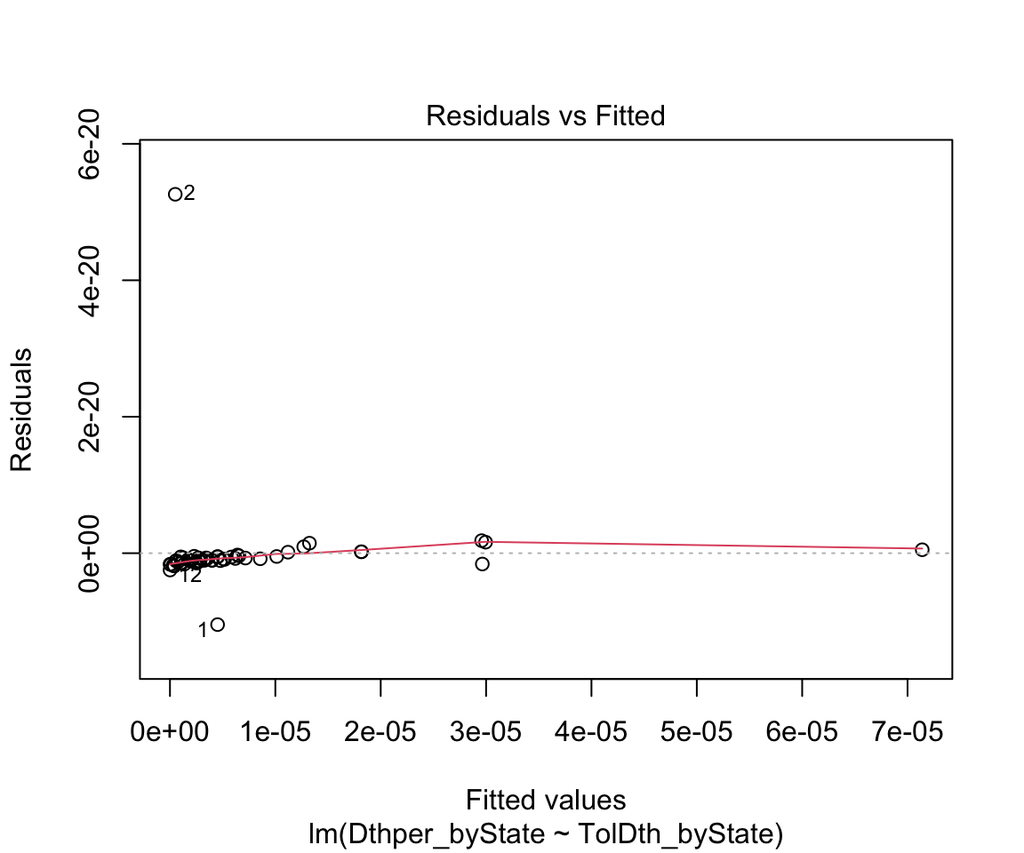

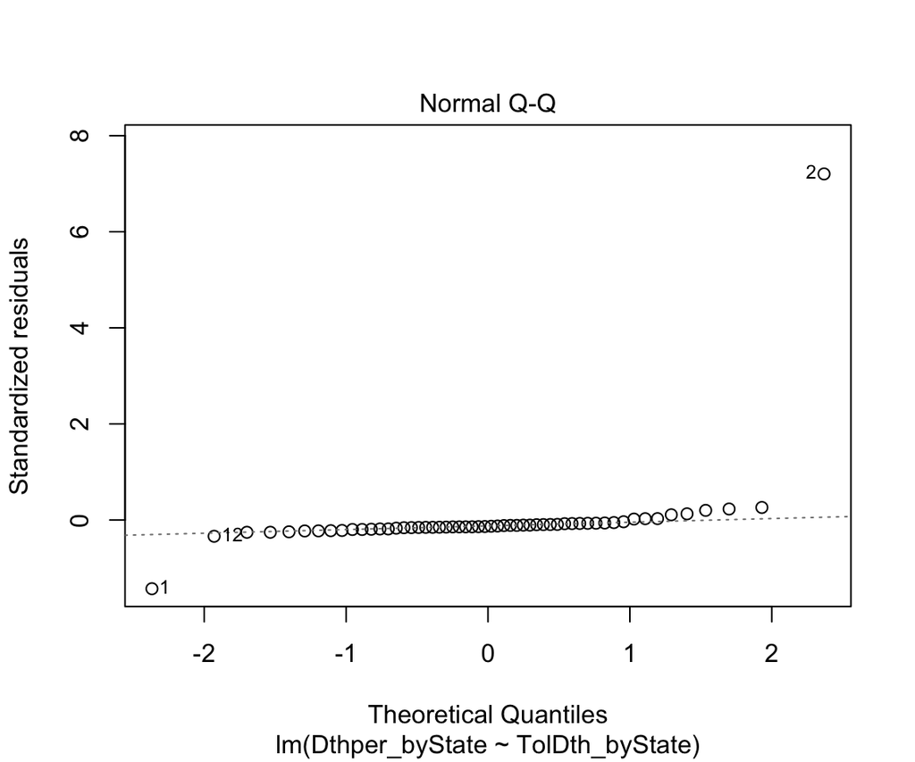

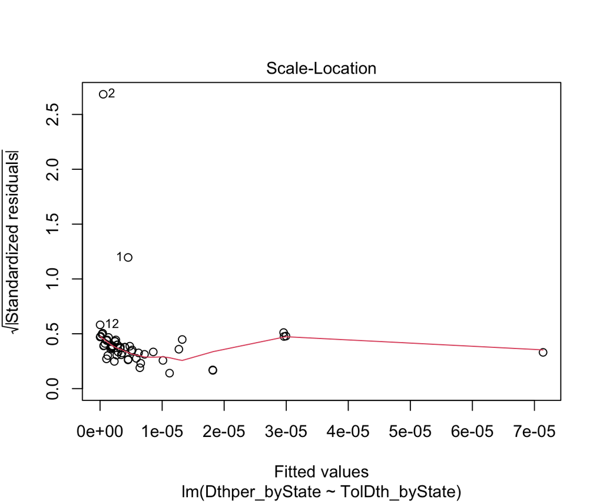

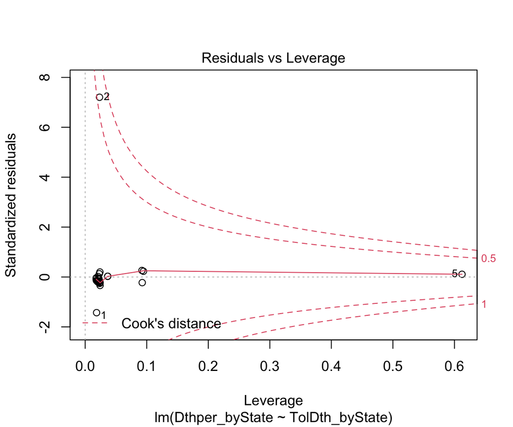

```r
plot(lmout2)
```

```r
# Based on the result, the p-value < 0.05 which suggests that there is enough evidence to say that there is a linear relationship between total deaths and deaths per population. Adjusted R-squared is 1, meaning 100% of the variation is explained by the regression model, so we can say that this is a good model
```